# Homework_4

Quinn Dellinger

10/15/2019

## HW 4 Problems

Below you will find problems for you to complete as an individual. It is fine to discuss the homework problems with classmates, but cheating is prohibited and will be harshly penalized if detected.

**For all problems below, only use base R plotting methods. Do not use tidyverse plotting methods.**

### 1. Read https://data.cityofchicago.org/Health-Human-Services/Food-Inspections/4ijn-s7e5/ for more information about the [Chicago Food Inspections Data](https://uofi.box.com/shared/static/5637axblfhajotail80yw7j2s4r27hxd.csv) and do the following:

1. create a visualization (plot) of at least two variables (excluding ID or label variables) using this dataset

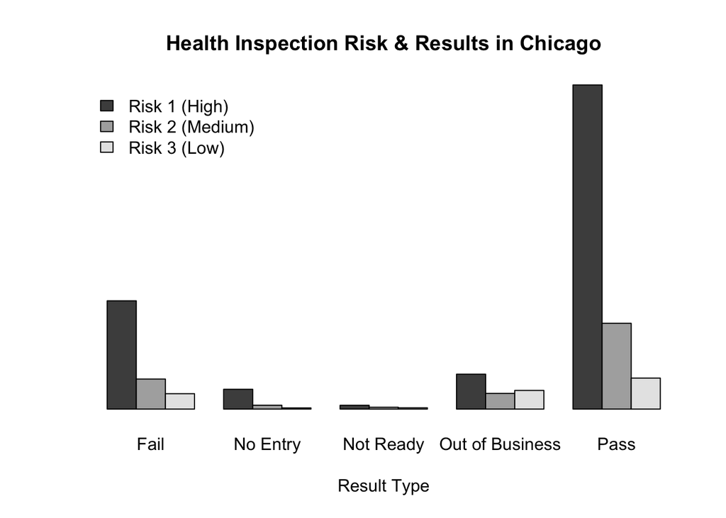

```r
food_data<-read.csv("Food_Inspections.csv")
results <- food_data$Results
risk <- food_data$Risk
hmm <- t(table(results,risk))
hmm <- hmm[3:5,2:6]
barplot(hmm, beside = T, legend.text = c("Risk 1 (High)","Risk 2 (Medium)","Risk 3 (Low)"), main = "Health Inspection Risk & Results in Chicago", xlab = "Result Type", axes = F, args.legend = list(bty = "n",x = "topleft"))
```

2. explain what is good and what is bad about the visualization

The graph lets us see easily for each category of test result what kind of safety risk the business posed upon inspection, but there’s a lot of data categories to go through.

3. show a substantially improved visualization

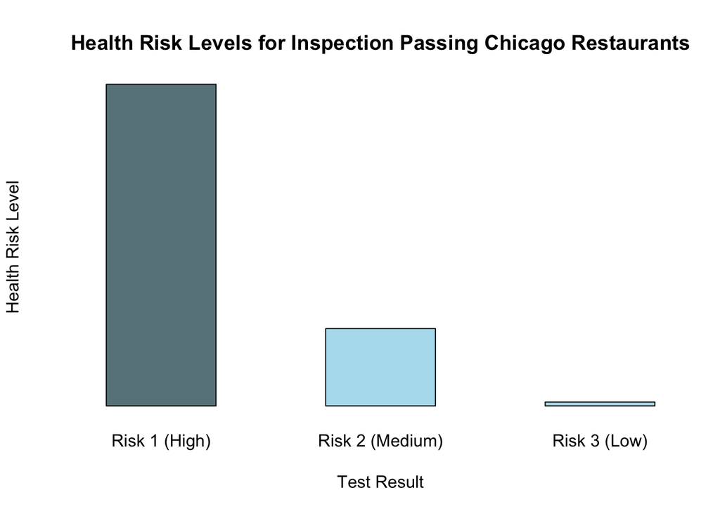

```r
restaurant<-which(food_data$Facility.Type == "Restaurant")
passers<-which(food_data$Results == "Pass")
passing_restaurants<-intersect(restaurant,passers)
restaurant_risk<-food_data$Risk[passing_restaurants]
restaurant_risk<-factor(restaurant_risk)
restaurant_results<-food_data$Results[passing_restaurants]
restaurant_results<-factor(restaurant_results)
hmm2 <- table(restaurant_results, restaurant_risk)
barplot(hmm2, beside = T, main = "Health Risk Levels for Inspection Passing Chicago Restaurants", xlab = "Test Result", ylab = "Health Risk Level", col = c("lightblue4","lightblue2","lightblue"), axes = F)
```

4. describe the improvement and why the improved plot in **part 1c** helps the reader or viewer more than the original plot in **part 1a**.

The improvement is meant to focus on a specific subset of data, in this case restaurants, and the graph makes it very apparant what result should be gleamed from the data. Color shading is added to make it look nicer; white space is utilized to make viewing easier, and the most important data, that being the high risk restaurants, is viewed first, being that it’s at the top left.